# 自然语言处理实验一实验报告

## 基于不同文本表示的新闻文本分类

姓名：李冉婧 学号：2310511 专业：信息安全

# 一、实验目的

1. 理解不同文本表示方法的基本思想；
2. 掌握文本分类任务的基本实验流程；
3. 熟悉 Logistic Regression 在文本分类中的使用；
4. 掌握 Word2Vec、GloVe 等词向量的基本使用方法；
5. 熟悉 BERT 类预训练语言模型的 Fine-tuning 流程；
6. 能够使用 Accuracy 和 Macro-F1 对文本分类模型进行评价；
7. 能够对不同文本表示方法的性能进行基本比较和分析。

# 二、实验环境

本实验在 Windows 11 下使用 Python 3.13 虚拟环境完成，主要依赖 scikit-learn、gensim、PyTorch 和 Transformers。具体环境如下：

| 组件 | 版本 |
| --- | --- |
| 操作系统 | Windows 11 |
| GPU | NVIDIA GeForce RTX 4060 Laptop GPU (8GB) |
| CUDA | 12.8 |
| Python | 3.13.9 (Anaconda base, venv) |
| NumPy | 2.5.3 |
| pandas | 3.0.6 |
| SciPy | 1.18.1 |
| scikit-learn | 1.9.1 |
| NLTK | 3.10.3 |
| gensim | 4.4.0 |
| PyTorch | 2.11.0+cu128 |
| Transformers | 5.17.0 |

数据集为 `submission/data/nyt.csv`（11,519 条，3 类）和 `submission/data/ag.csv`（90,000 条，仅用于训练 Word2Vec）。

为隔离不同项目的依赖并保证实验可复现，本实验使用独立的 Python 虚拟环境 `submission/.venv-bert`。所有实验代码均通过该虚拟环境中的解释器运行，不直接使用 Anaconda 基础环境，从而避免与全局环境中的 scipy、scikit-learn 等包发生版本冲突。

# 三、知识背景

## 3.1 文本分类的基本流程

文本分类通常分为以下步骤：

```
原始文本
  -> 分词与规范化
  -> 文本表示（特征提取）
  -> 训练分类器
  -> 在验证集上检查或选择模型
  -> 在测试集上计算 Accuracy 和 Macro-F1
```

核心原则是：

- 词表、词频等统计量只能从 Training Set 获得；
- Validation Set 用于监控或选择模型；
- Test Set 只做最终评价，不能反复调参；
- 所有方法使用同一份数据划分，保证可比性。

## 3.2 分词与词表

BoW 和 Word2Vec 使用统一分词规则：

1. 文本转为小写；
2. 使用 NLTK `TreebankWordTokenizer` 分词；
3. 删除不含字母或数字的纯标点 token；
4. 保留数字及混合 token。

词表是从训练集统计得到的所有不同词组成的集合：

$$V=\{w_1,w_2,\dots,w_{|V|}\}$$

其中 $|V|$ 表示词表大小。

## 3.3 Bag-of-Words 原理

Bag-of-Words 把一篇文档表示为一个 $|V|$ 维向量，并忽略词序。

Binary Bag-of-Words 只记录词是否出现：

$$x_i=
\begin{cases}
1,& w_i\text{ 在文档中出现}\\
0,& w_i\text{ 未出现}
\end{cases}$$

Word Frequency 记录词的出现次数：

$$x_i=\text{词 }w_i\text{ 在当前文档中的出现次数}$$

BoW 的优点是简单、可解释、训练快；缺点是维度高且稀疏，无法表示词序和语义相似关系。

## 3.4 Logistic Regression 原理

Logistic Regression 用于多分类时，对类别 $c$ 计算线性得分：

$$z_c=w_c^\top x+b_c$$

再通过 Softmax 把得分转为概率：

$$P(y=c\mid x)=\frac{e^{z_c}}{\sum_{k=1}^{K}e^{z_k}}$$

训练时最小化交叉熵损失：

$$L=-\frac{1}{N}\sum_{i=1}^{N}\log P(y_i\mid x_i)$$

本实验中，所有 Logistic Regression 使用相同配置：`C=1.0`、`solver="lbfgs"`、`max_iter=2000`、`random_state=42`。

## 3.5 Word2Vec 原理

Word2Vec 学习每个词的稠密低维向量，其基本假设是：出现在相似上下文中的词往往具有相似含义。

CBOW 根据上下文词预测中心词，目标是最大化：

$$\sum_{t}\log P(w_t\mid w_{t-c},\dots,w_{t-1},w_{t+1},\dots,w_{t+c})$$

Skip-gram 根据中心词预测上下文词，目标是最大化：

$$\sum_{t}\sum_{-c\le j\le c,\,j\ne 0}\log P(w_{t+j}\mid w_t)$$

本实验使用 Skip-gram 结构。训练得到的词向量可用于表示文档。

## 3.6 GloVe 原理

GloVe 利用全局词共现信息学习词向量。它先统计词 $w_i$ 和 $w_j$ 共同出现的次数 $X_{ij}$，然后让词向量内积近似表示共现的对数：

$$w_i^\top \tilde w_j+b_i+\tilde b_j \approx \log X_{ij}$$

本实验直接使用公开的 `glove.6B.100d` 预训练词向量。

## 3.7 文档向量的平均池化

对于一篇包含 $n$ 个有效词的文档，文档向量通过对所有有效词向量求平均得到：

$$e(d)=\frac{1}{n}\sum_{i=1}^{n}e(w_i)$$

如果某个词不在词向量表中，则视为 OOV 词并忽略。若一篇文档没有任何有效词，则使用零向量。

## 3.8 BERT 原理

BERT 基于 Transformer 的自注意力机制，能够根据上下文动态表示每个词。自注意力中，词与词之间通过注意力权重交互：

$$\text{Attention}(Q,K,V)=\text{softmax}\left(\frac{QK^\top}{\sqrt{d_k}}\right)V$$

BERT 使用 `[CLS]` token 的表示接入分类层。本实验使用 `google-bert/bert-base-uncased`，在分类任务上端到端微调：

```
[CLS] 表示 -> Dropout -> Linear -> Softmax -> 3 类概率
```

## 3.9 评价指标

Accuracy 为预测正确样本占全部测试样本的比例：

$$ACC=\frac{\text{预测正确的样本数}}{\text{测试样本总数}}$$

对每个类别分别计算 Precision、Recall 和 F1：

$$Precision=\frac{TP}{TP+FP},\quad
Recall=\frac{TP}{TP+FN},\quad
F1=\frac{2PR}{P+R}$$

Macro-F1 对所有类别的 F1 取平均：

$$Macro\text{-}F1=\frac{1}{K}\sum_{c=1}^{K}F1_c$$

本实验数据中 sports 约占 75%，因此 Accuracy 容易偏高，必须同时使用 Macro-F1 观察少数类表现。

# 四、实验内容与步骤

## 4.1 数据与划分

NYT 数据包含 `text` 和 `label` 两列，类别为 `business`、`politics`、`sports`：

| 类别 | 样本数 | 占比 |
| --- | --- | --- |
| business | 1,429 | 12.40% |
| politics | 1,451 | 12.60% |
| sports | 8,639 | 74.99% |

数据采用分层随机划分：

```python
train, temp = train_test_split(
    df, test_size=0.20, random_state=42, stratify=df["label"]
)
val, test = train_test_split(
    temp, test_size=0.50, random_state=42, stratify=temp["label"]
)
```

得到：

| 类别 | Training | Validation | Test |
| --- | --- | --- | --- |
| business | 1,143 | 143 | 143 |
| politics | 1,161 | 145 | 145 |
| sports | 6,911 | 864 | 864 |

所有任务都读取同一份划分，保证比较公平。

## 4.2 统一预处理

BoW 和 Word2Vec 共用分词函数：

```python
def tokenize_text(text: str) -> list[str]:
    tokens = _TOKENIZER.tokenize(str(text).lower())
    return [token for token in tokens if any(ch.isalnum() for ch in token)]
```

BERT 使用其自身的 WordPiece Tokenizer，不能复用上述分词结果，因为 Transformer 模型必须使用与预训练模型匹配的分词器。

## 4.3 Task 1：Bag-of-Words

1. 在 Training Set 上构建词表，得到 142,077 个词；
2. 分别生成 Binary BoW 和 Word Frequency 稀疏矩阵；
3. 使用 Logistic Regression 训练；
4. 在 Test Set 上计算 Accuracy 和 Macro-F1。

运行命令：

```powershell
.\.venv-bert\Scripts\python.exe src\task1_bow.py
```

## 4.4 Task 2：Word2Vec / GloVe

三种表示统一使用 100 维词向量：

1. 加载 GloVe 100d；
2. 使用 AG News 90,000 条文本训练 Word2Vec；
3. 使用 NYT Training Set 9,215 条文本训练 Word2Vec；
4. 对每篇文档取有效词向量的平均；
5. 使用 Logistic Regression 训练。

Word2Vec 参数为：

| 参数 | 值 |
| --- | --- |
| vector_size | 100 |
| window | 5 |
| min_count | 5 |
| 结构 | Skip-gram |
| negative | 5 |
| epochs | 5 |
| seed | 42 |

运行命令：

```powershell
.\.venv-bert\Scripts\python.exe src\task2_word2vec.py
```

## 4.5 Task 3：BERT 微调

| 项目 | 配置 |
| --- | --- |
| 模型 | `google-bert/bert-base-uncased` |
| 最大序列长度 | 64 |
| 训练轮数 | 3 epochs |
| Batch size | 32 |
| 优化器 | AdamW |
| 学习率 | 2e-5 |
| Weight decay | 0.01 |

训练 3 个 epoch，每个 epoch 后在 Validation Set 上计算 Macro-F1，最终选择验证集 Macro-F1 最高的模型在 Test Set 上评价。

运行命令：

```powershell
.\.venv-bert\Scripts\python.exe src\task3_bert.py --model-name cache\bert-base-uncased-local
```

# 五、实验结果与分析

## 5.1 Task 1 结果

| 表示方法 | Validation Accuracy | Validation Macro-F1 | Test Accuracy | Test Macro-F1 | 错分数 |
| --- | --- | --- | --- | --- | --- |
| Binary BoW | 0.9818 | 0.9562 | 0.9887 | 0.9718 | 13 |
| Word Frequency | 0.9809 | 0.9576 | 0.9922 | 0.9802 | 9 |

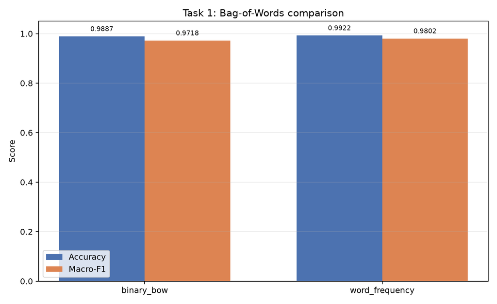

Task 1 对比

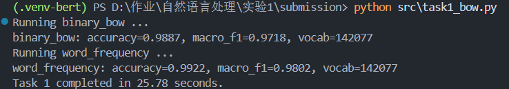

截图1：Task 1 运行结果

Word Frequency 的 Test Accuracy 比 Binary BoW 高约 0.35 个百分点，Macro-F1 高约 0.83 个百分点，错误数由 13 条减少到 9 条。保留词频后，模型能利用重复出现的关键词增强类别判断，对 business 类改善最明显。

两种方法的错误主要发生在 business 和 politics 之间。Logistic Regression 的高权重词符合新闻直觉：business 常见 `company`、`market`、`bank`，politics 常见 `washington`、`republican`、`obama`，sports 常见 `game`、`team`、`league`。

## 5.2 Task 2 结果

| 表示方法 | Test Accuracy | Test Macro-F1 | 错分数 |
| --- | --- | --- | --- |
| GloVe 6B 100d | 0.9618 | 0.9119 | 44 |
| Word2Vec on AG News | 0.9583 | 0.9067 | 48 |
| Word2Vec on NYT | 0.9696 | 0.9313 | 35 |

[figure not shown]

Task 2 对比

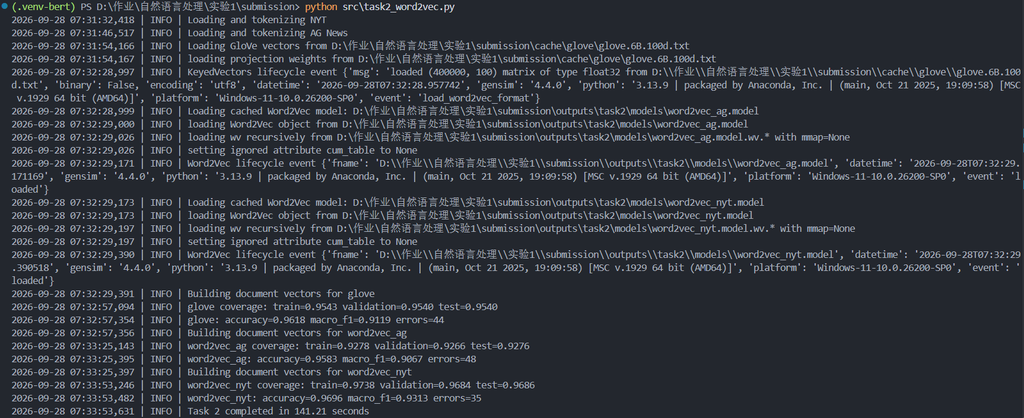

截图2：Task 2 运行结果

### 5.2.1 OOV 与覆盖率

| 表示方法 | 词表大小 | Test token 覆盖率 | Test OOV 类型率 | 平均有效词数 |
| --- | --- | --- | --- | --- |
| GloVe | 400,000 | 95.40% | 36.58% | 628.52 |
| Word2Vec on AG News | 26,072 | 92.76% | 63.59% | 611.08 |
| Word2Vec on NYT | 34,765 | 96.86% | 43.74% | 638.11 |

NYT Word2Vec 的训练语料与测试任务同域，因此测试 token 覆盖率最高，分类效果也最好。AG News Word2Vec 词表最小、OOV 类型率最高，是三种词向量中表现最弱的原因之一。GloVe 词表覆盖广，优于 AG News Word2Vec，但领域适配程度不如 NYT Word2Vec。

### 5.2.2 与 BoW 的比较

三种词向量的 Macro-F1 都低于 Task 1 的 Bag-of-Words。原因是平均池化把整篇文档压缩为 100 维向量，丢失词序和关键词强度；长新闻中大量背景内容会稀释分类特征。而高维稀疏 BoW 能直接利用具体关键词，在这类类别词汇差异明显的任务中仍然有效。

## 5.3 Task 3 结果

| 指标 | 值 |
| --- | --- |
| Test Accuracy | 0.9852 |
| Test Macro-F1 | 0.9684 |
| 最佳 epoch | 2 |
| 最佳 Validation Macro-F1 | 0.9457 |
| 错分样本数 | 17 |

逐轮训练记录：

| Epoch | Train Loss | Validation Loss | Validation Accuracy | Validation Macro-F1 |
| --- | --- | --- | --- | --- |
| 1 | 0.2807 | 0.0819 | 0.9731 | 0.9411 |
| 2 | 0.0486 | 0.0835 | 0.9748 | 0.9457 |
| 3 | 0.0217 | 0.0986 | 0.9714 | 0.9386 |

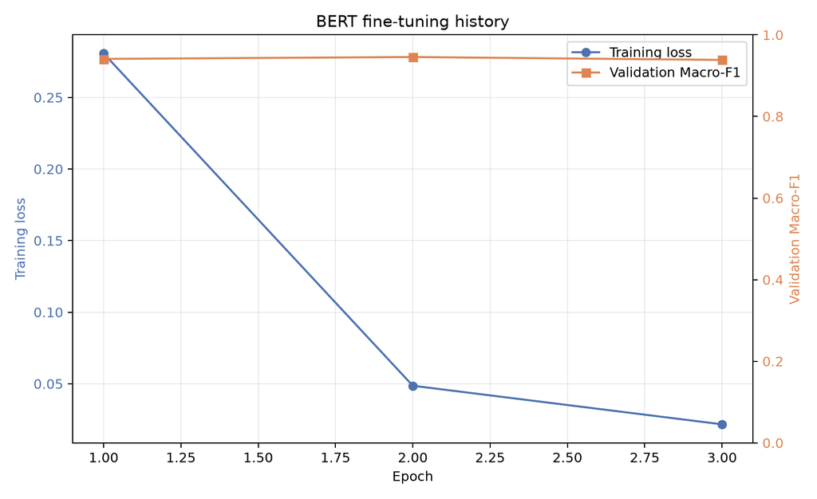

BERT 训练曲线

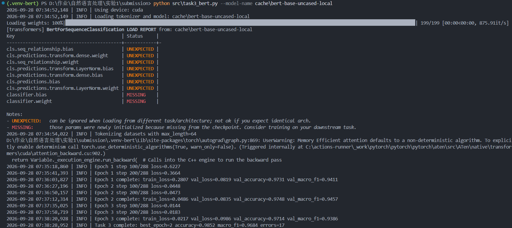

截图3：Task 3 运行结果

分类别结果：

| 类别 | Precision | Recall | F1-score | Support |
| --- | --- | --- | --- | --- |
| business | 0.9643 | 0.9441 | 0.9541 | 143 |
| politics | 0.9459 | 0.9655 | 0.9556 | 145 |
| sports | 0.9954 | 0.9954 | 0.9954 | 864 |

BERT 相比三种平均词向量明显提升了少数类表现。但由于 `max_length=64`，几乎所有文档都被截断：

| 数据集 | 平均 token 数 | 超过 64 token 的比例 |
| --- | --- | --- |
| Training | 833.44 | 99.95% |
| Validation | 831.13 | 100.00% |
| Test | 851.56 | 100.00% |

因此 BERT 只能看到新闻导语，而 BoW 可以看到全文。这解释了为什么本实验中 BERT 略低于 Word Frequency 词袋。

## 5.4 六种方法最终对比

| Task | 方法 | Test Accuracy | Test Macro-F1 |
| --- | --- | --- | --- |
| 1 | Binary BoW | 0.9887 | 0.9718 |
| 1 | Word Frequency | 0.9922 | 0.9802 |
| 2 | GloVe 6B 100d | 0.9618 | 0.9119 |
| 2 | Word2Vec on AG News | 0.9583 | 0.9067 |
| 2 | Word2Vec on NYT | 0.9696 | 0.9313 |
| 3 | BERT-base-uncased | 0.9852 | 0.9684 |

六种方法的混淆矩阵保存在 `outputs/task1`、`outputs/task2`、`outputs/task3` 对应目录中。

# 六、实验总结

本次实验完成了三种文本表示方法在 NYT 新闻三分类任务上的比较。

在 Bag-of-Words 部分，Binary BoW 和 Word Frequency 都取得了很高效果，其中 Word Frequency 因保留词频信息而优于 Binary BoW，说明在新闻分类中关键词强度是有用的判别信号。

在 Word2Vec 部分，NYT 领域内训练的 Word2Vec 优于 GloVe 和 AG News Word2Vec。领域一致性越高、OOV 越少，平均文档向量越稳定。同时发现，平均词向量在这类长文本、类别词特征明显的任务中不如高维稀疏词袋。

在 BERT 部分，上下文表示和端到端微调使少数类表现明显优于平均词向量方法。但由于题目固定 `max_length=64`，模型只能看到文档开头，最终 Macro-F1 略低于 Word Frequency。

整体而言，本实验最重要的收获是：文本表示方法没有绝对的优劣，需要结合任务特点、文本长度和输入限制来分析。当类别关键词特征明显时，简单词袋可能更强；当需要上下文语义时，BERT 更有优势，但其效果也受到截断长度的约束。

# 七、复现方式

在 `submission` 目录运行：

```powershell
.\run_all.ps1
```

脚本会自动准备环境、下载 GloVe 和 BERT 权重，并依次运行三个任务。BERT 权重使用 ModelScope 上 `AI-ModelScope/bert-base-uncased` 仓库下载，该仓库与 `google-bert/bert-base-uncased` 是同一模型。